# Teste de Kruskal-Wallis

2022-07-12

## Introdução

- Este teste é uma alternativa não paramétrica do método da ANOVA;
- Serve para contrastar a hipótese de que **k** amostras quantitativas tenham sido obtidas de uma mesma população.
- A única exigência versa sobre a aleatoriedade na extração das amostras, não fazendo referência a nenhuma das outras condições adicionais de homocedasticidade e normalidade necessárias para a aplicação do teste paramétrico ANOVA.

## Como se executa o teste de Kruskal-Wallis em R?

A função que se usa para executar este teste é:

kruskal.test(x ~ y, dados)

**x**= valores observados da variável resposta (em formato vetor de dados);

**y**= fator que define os grupos a comparar (em formato de fator). **dados**= dados em formato *data frame*.

## Exemplo 1

```r
peso<-c(32,37,34,33,30,36,38,37,30,34,35,30,36,29,31)
dieta<-factor(rep(LETTERS[1:3],c(5,5,5)))
galinhas <- data.frame(dieta,peso)
head(galinhas)
```

```
##   dieta peso
## 1     A   32
## 2     A   37
## 3     A   34
## 4     A   33
## 5     A   30
## 6     B   36
```

## Hipótese

H0: Não existem diferenças entre as dietas ofertadas com relação ao aumento de peso das galinhas;

H1: Existem diferenças significativas entre as dietas para o aumento de peso das galinhas.

## Exemplo 1

```r
kruskal.test(peso~dieta, galinhas)
```

```
##
##  Kruskal-Wallis rank sum test
##
## data:  peso by dieta
## Kruskal-Wallis chi-squared = 2.2937, df = 2, p-value = 0.3176
```

## Conclusão exemplo 1

- O p-value= 0.3176 é suficientemente grande para aceitar a hipótese nula.
- Se aceita a hipótese nula de igualdade dos efeitos das 3 dietas em relação ao aumento de peso das galinhas.

## Exemplo 2

Com o objetivo de analisar se existem diferenças significativas, na longevidade (dias) de adultos da mariposa *Duponchelia fovealis* (Lepidoptera: Crambidae), alimentadas com 4 dietas alimentares, foi conduzido um experimento em laboratório em delineamento inteiramente casualizado, obtendo-se os seguintes resultados:

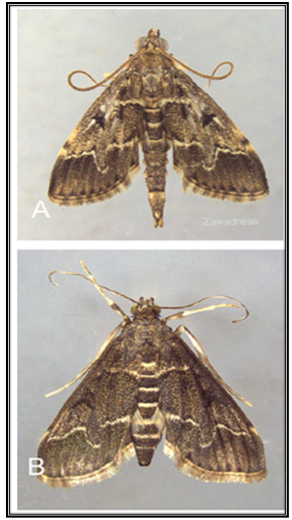

## Dados

```r
longevidade<-c(47,43,34,13,29,12,17,10,39,15,1,12,6,7,1,3,27,7,5,2)
dieta<-factor(rep(LETTERS[1:4],c(5,5,5,5)))

Mariposa <- data.frame(dieta,longevidade)
head(Mariposa)
```

```
##   dieta longevidade
## 1     A          47
## 2     A          43
## 3     A          34
## 4     A          13
## 5     A          29
## 6     B          12
```

## Hipótese

H0: Não existem diferenças entre as dietas ofertadas com relação ao aumento de longevidade das mariposas;

H1: Existem diferenças significativas entre as dietas para o aumento de longevidade das mariposas.

## Investigando teus dados! **Histograma**

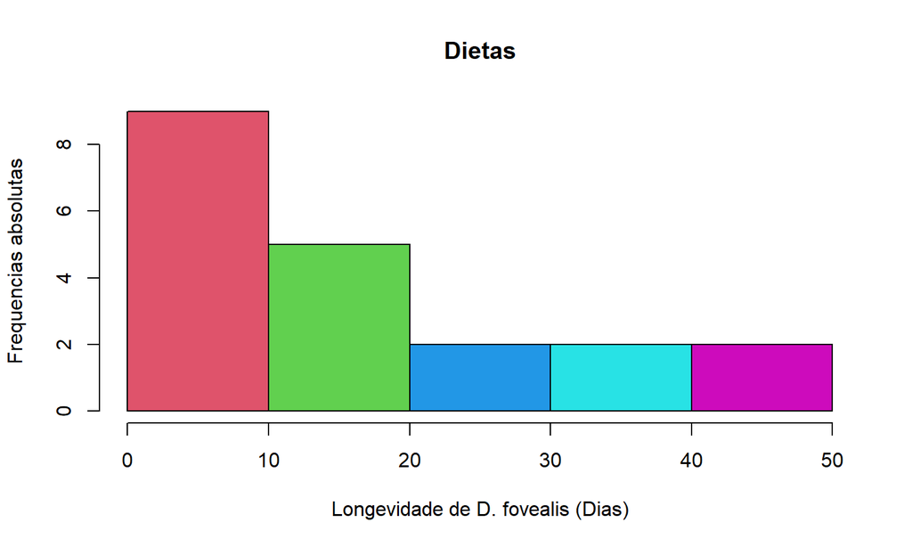

```r
hist(Mariposa$longevidade, col=c(2,3,4,5,6,7,8,9), main = "Dietas",
     xlab = "Longevidade de D. fovealis (Dias)",
     ylab= "Frequencias absolutas")
```

## Gráfico de qqnorm

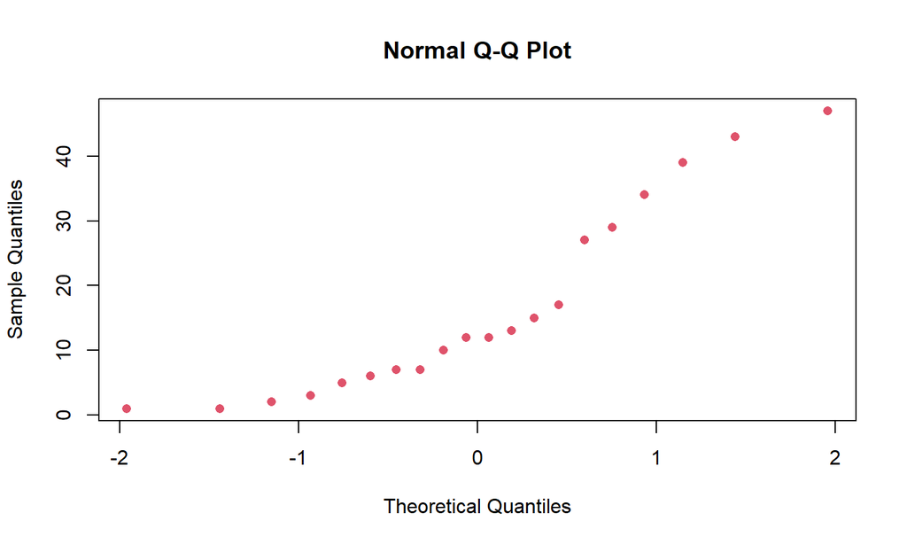

```r
qqnorm(Mariposa$longevidade, pch=16, col=2)
```

## Boxplot

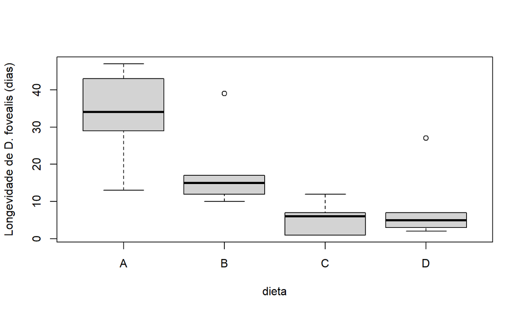

```r
boxplot(longevidade ~ dieta,
        data = Mariposa, ylab = "Longevidade de D. fovealis (dias)")
```

## Teste de homogenicidade das variâncias - Bartlett test

```r
bartlett.test(longevidade ~ dieta, data= Mariposa)
```

```
##
##  Bartlett test of homogeneity of variances
##
## data:  longevidade by dieta
## Bartlett's K-squared = 3.6213, df = 3, p-value = 0.3054
```

## Médias e desvio padrão

```r
aggregate (longevidade ~ dieta,
           data = Mariposa, rm.na= TRUE,mean) # Médias dos tratamentos
```

```
##   dieta longevidade
## 1     A        33.2
## 2     B        18.6
## 3     C         5.4
## 4     D         8.8
```

```r
aggregate (longevidade ~ dieta, data = Mariposa,sd) # Desvio padrão
```

```
##   dieta longevidade
## 1     A   13.349157
## 2     B   11.717508
## 3     C    4.615192
## 4     D   10.353743
```

## Longevidade (dias), teste de normalidade

```r
shapiro.test(Mariposa$longevidade[Mariposa$dieta=="A"])
```

```
##
##  Shapiro-Wilk normality test
##
## data:  Mariposa$longevidade[Mariposa$dieta == "A"]
## W = 0.94668, p-value = 0.7135
```

```r
shapiro.test(Mariposa$longevidade[Mariposa$dieta=="B"])
```

```
##
##  Shapiro-Wilk normality test
##
## data:  Mariposa$longevidade[Mariposa$dieta == "B"]
## W = 0.76381, p-value = 0.03976
```

```r
shapiro.test(Mariposa$longevidade[Mariposa$dieta=="C"])
```

```
##
##  Shapiro-Wilk normality test
##
## data:  Mariposa$longevidade[Mariposa$dieta == "C"]
## W = 0.90051, p-value = 0.4127
```

```r
shapiro.test(Mariposa$longevidade[Mariposa$dieta=="D"])
```

```
##
##  Shapiro-Wilk normality test
##
## data:  Mariposa$longevidade[Mariposa$dieta == "D"]
## W = 0.72086, p-value = 0.01563
```

## Teste de Kruskal-Wallis

```r
kruskal.test(longevidade~dieta, Mariposa)
```

```
##
##  Kruskal-Wallis rank sum test
##
## data:  longevidade by dieta
## Kruskal-Wallis chi-squared = 12.087, df = 3, p-value = 0.00709
```

## Dunn.test - Separação de médias

- Inicialmente vamos carregar o pacote “FSA”

```r
library(FSA)
```

## Dunn.test

```r
dunnTest(longevidade ~ dieta,
         data=Mariposa,
         method="bonferroni")
```

```
## Dunn (1964) Kruskal-Wallis multiple comparison
```

```
##   p-values adjusted with the Bonferroni method.
```

```
##   Comparison          Z     P.unadj      P.adj
## 1      A - B  1.0434964 0.296718455 1.00000000
## 2      A - C  3.0502202 0.002286736 0.01372042
## 3      B - C  2.0067238 0.044779079 0.26867447
## 4      A - D  2.6488754 0.008076009 0.04845606
## 5      B - D  1.6053791 0.108410412 0.65046247
## 6      C - D -0.4013448 0.688166311 1.00000000
```

## Médias, desvio padrão e erro padrão

- Forma 1 de calcular erro padrão

```r
mean(Mariposa$longevidade[Mariposa$dieta=="A"]) # Médias dos tratamentos
```

```
## [1] 33.2
```

```r
sd (Mariposa$longevidade[Mariposa$dieta=="A"]) # Desvio padrão
```

```
## [1] 13.34916
```

```r
se <- c(sd (Mariposa$longevidade[Mariposa$dieta=="A"])/sqrt(5))
se # erro padrão
```

```
## [1] 5.969925
```

## Forma 2 de calcular erro padrão

```r
library(plotrix)
std.error(Mariposa$longevidade[Mariposa$dieta=="A"])
```

```
## [1] 5.969925
```

```r
std.error(Mariposa$longevidade[Mariposa$dieta=="B"])
```

```
## [1] 5.240229
```

```r
std.error(Mariposa$longevidade[Mariposa$dieta=="C"])
```

```
## [1] 2.063977
```

```r
std.error(Mariposa$longevidade[Mariposa$dieta=="D"])
```

```
## [1] 4.630335
```

## Resultado final

```r
Longevidade_media <- c(33.2,18.6,5.4,8.8)
Dietas <- c("A","B", "C", "D")
SE <- c("5.97", "5.24", "2.06","4.63")
signif <- c("a","ab", "b", "b")
Dupon <- data.frame(Dietas,Longevidade_media, SE,signif)
head(Dupon)
```

```
##   Dietas Longevidade_media   SE signif
## 1      A              33.2 5.97      a
## 2      B              18.6 5.24     ab
## 3      C               5.4 2.06      b
## 4      D               8.8 4.63      b
```

## Conclusão do exemplo 2

- As dietas influenciam significativamente (p-value <0.01) a longevidade da mariposa *D. fovealis* (Lepidoptera: Crambidae).
- As dietas A e B foram os tratamentos que proporcionaram em média as maiores longevidades para as mariposas.

## Referências

Pérez, Garcia, A. Estadística aplicada com R. UNED, Madrid, 2012.

## Muito obrigada!

Emily Silva Araujo

araujosemily@gmail.com